# Data115_2025Spring_PS2_Team7_Calderon_Hammad

#### 4. Load the data in `Height_Weight_Age_Sex` as a dataframe in Python.

##### (a) Create boxplots for the height and weight columns separately. Comment on the symmetry and skewness, if any, for their distributions using these plots.

##### (b) Create histograms for the height and weight columns separately. Comment on the symmetry and skewness, if any, for their distributions using these plots. Are your conclusions based on the boxplots consistent with those based on densities?

##### (c) Create separate boxplots for the weight data separated by the male variable. What do you observe about the two distributions?

##### (d) Define variable `BMI`, applying the [formula for metric system](https://www.thecalculatorsite.com/articles/health/bmi-formula-for-bmi-calculations.php): $BMI = Weight / (\frac{Height}{100})^2$. Create a binary indicator variable `Underweight` that takes value "1" for individuals with BMI < 18.5 and value "0" otherwise. Add both of these variables as a columns to the dataframe.

##### (e) Create separate histograms for the BMI column separated by the male variable. What do you observe about the two distributions?

##### (f) Make a scatterplot of height vs. weight for the full dataset that distinguishes both the male variable and the underweight variable. What do you observe?

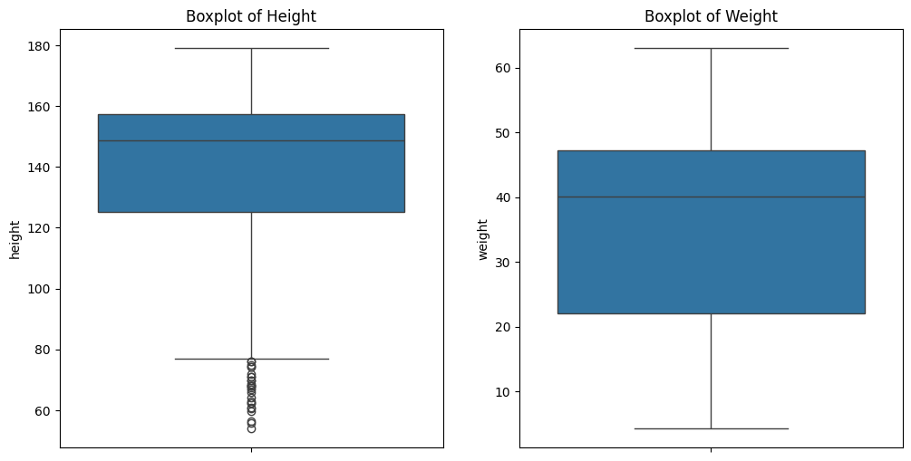

```python
import pandas as pd
import matplotlib.pyplot as plt
import seaborn as sns

df = pd.read_csv('Height_Weight_Age_Sex.csv')
plt.figure(figsize=(12, 6))

plt.subplot(1, 2, 1)
sns.boxplot(y=df['height'])  # Use 'height' instead of 'Height'
plt.title('Boxplot of Height')

plt.subplot(1, 2, 2)
sns.boxplot(y=df['weight'])  # Use 'weight' instead of 'Weight'
plt.title('Boxplot of Weight')

plt.show()
```

(b) both histograms for height and weight are skewed to the left. There are some very short people causing this, which pulls the average left (down) even though most samples are bigger larger. Similarly we see the left skew of the weight plot, due to a some very light people pulling the average down. So, both of these means will be lower than the median.

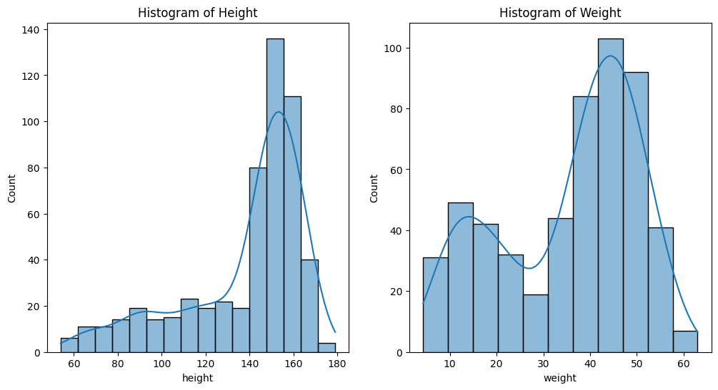

```python
df = pd.read_csv('Height_Weight_Age_Sex.csv')
plt.figure(figsize=(12, 6))

plt.subplot(1, 2, 1)
sns.histplot(df['height'], kde=True)
plt.title('Histogram of Height')

plt.subplot(1, 2, 2)
sns.histplot(df['weight'], kde=True)
plt.title('Histogram of Weight')

plt.show()
```

#### (c) the boxplot is left skewed since the median is closer to the top and the tail is shorter

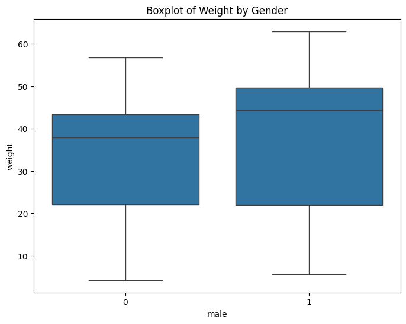

```python
df = pd.read_csv('Height_Weight_Age_Sex.csv')
plt.figure(figsize=(8, 6))
sns.boxplot(x='male', y='weight', data=df)
plt.title('Boxplot of Weight by Gender')
plt.show()
```

#### (d)

```python
df = pd.read_csv('Height_Weight_Age_Sex.csv')
df['BMI'] = df['weight'] / (df['height'] / 100) ** 2
df['Underweight'] = (df['BMI'] < 18.5).astype(int)
print(df.head())
```

```
    height     weight   age  male        BMI  Underweight
0  151.765  47.825606  63.0     1  20.764297            0
1  139.700  36.485807  63.0     0  18.695244            0
2  136.525  31.864838  65.0     0  17.095718            1
3  156.845  53.041914  41.0     1  21.561444            0
4  145.415  41.276872  51.0     0  19.520384            0
```

#### (e) the bmi distribution of males on the histogram is approximately symetrical, but females histogram looks left skewed and a longer tail towards lower values

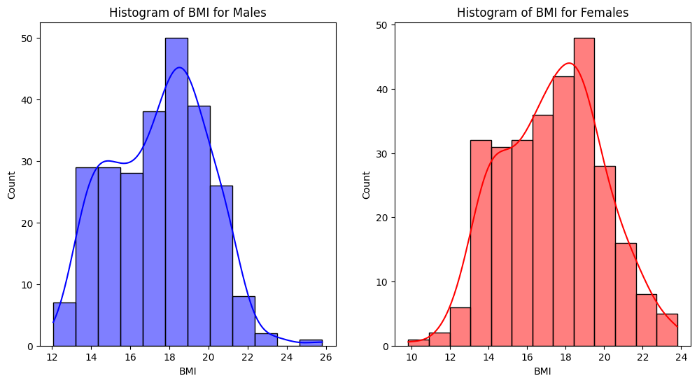

```python
plt.figure(figsize=(12, 6))
plt.subplot(1, 2, 1)
sns.histplot(df[df['male'] == 1]['BMI'], kde=True, color='blue', label='Male')
plt.title('Histogram of BMI for Males')
plt.subplot(1, 2, 2)
sns.histplot(df[df['male'] == 0]['BMI'], kde=True, color='red', label='Female')
plt.title('Histogram of BMI for Females')
plt.show()
```

#### (f) the scatterplot shows us the correlation between weight and gender and height

#### 1.Males tend to have a higher weight than females

#### 2. as height increases the weight increases aswell

#### 3. underweight individuals are scattered throughout different heights but they tend to be more at lower heights

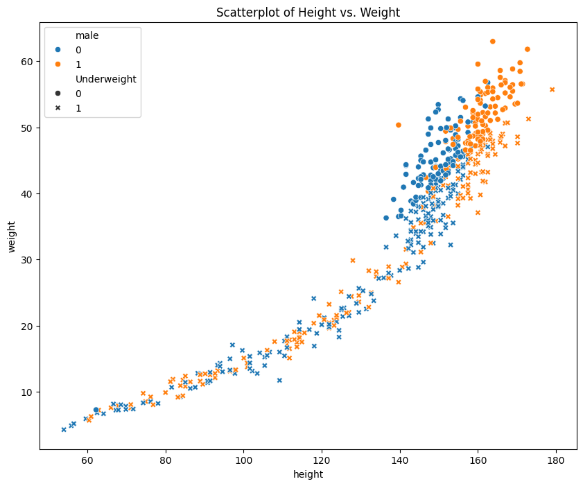

```python
plt.figure(figsize=(10, 8))
sns.scatterplot(x='height', y='weight', hue='male', style='Underweight', data=df)
plt.title('Scatterplot of Height vs. Weight')
plt.show()
```

#### 5. Read the following examples about Simpson’s Paradox: [How to lie with statistics?](https://people.eecs.berkeley.edu/%7Edaw/teaching/cs70-s08/notes/n21.pdf). Fill in the following table with ratios of hits to attempts so that player A has a higher batting average in both season 1 and season 2 but player B has a higher overall batting average for the two seasons combined.

[output not shown]